# Risk Analysis

Shalaka Thakare

2022-11-02

Lending Club

Background

Problem Statement

Importing the Libraries

```r
library(tidyverse)
library(lubridate)
library(stringr)
library(pROC)
library(rpart)
library(ROCR)
library(caret)
library(ranger)
library(plotluck)
```

Loading the data…

```r
lcdf <- read_csv('C:/Users/sthaka3/Desktop/Credit_Risk_Project/lcData100K.csv')

# Checking number of rows and columns in the lc dataframe

cat('Number of rows = ', nrow(lcdf))
```

```
## Number of rows =  100000
```

```r
cat('\nNumber of columns  = ',ncol(lcdf))
```

```
##
## Number of columns  =  145
```

Exploring the data

```r
head(lcdf)
```

```
## # A tibble: 6 × 145
##   id    member_id loan_amnt funded…¹ funde…² term  int_r…³ insta…⁴ grade sub_g…⁵
##   <lgl> <lgl>         <dbl>    <dbl>   <dbl> <chr>   <dbl>   <dbl> <chr> <chr>
## 1 NA    NA            28000    28000   28000 36 m…    5.32    843. A     A1
## 2 NA    NA             6150     6150    6125 36 m…   13.3     208. C     C3
## 3 NA    NA             7200     7200    7200 36 m…   15.0     250. C     C5
## 4 NA    NA             4750     4750    4750 36 m…   15.3     165. C     C4
## 5 NA    NA             5000     5000    5000 36 m…   12.7     168. C     C2
## 6 NA    NA             9600     9600    9600 36 m…   15.0     333. C     C3
## # … with 135 more variables: emp_title <chr>, emp_length <chr>,
## #   home_ownership <chr>, annual_inc <dbl>, verification_status <chr>,
## #   issue_d <dttm>, loan_status <chr>, pymnt_plan <chr>, url <lgl>, desc <lgl>,
## #   purpose <chr>, title <chr>, zip_code <chr>, addr_state <chr>, dti <dbl>,
## #   delinq_2yrs <dbl>, earliest_cr_line <chr>, inq_last_6mths <dbl>,
## #   mths_since_last_delinq <dbl>, mths_since_last_record <dbl>, open_acc <dbl>,
## #   pub_rec <dbl>, revol_bal <dbl>, revol_util <dbl>, total_acc <dbl>, …
```

```r
summary(lcdf)
```

```
##     id          member_id        loan_amnt      funded_amnt    funded_amnt_inv
##  Mode:logical   Mode:logical   Min.   : 1000   Min.   : 1000   Min.   :  925
##  NA's:100000    NA's:100000    1st Qu.: 7000   1st Qu.: 7000   1st Qu.: 7000
##                                Median :10000   Median :10000   Median :10000
##                                Mean   :12736   Mean   :12736   Mean   :12731
##                                3rd Qu.:17000   3rd Qu.:17000   3rd Qu.:16975
##                                Max.   :35000   Max.   :35000   Max.   :35000
##
##      term              int_rate      installment         grade
##  Length:100000      Min.   : 5.32   Min.   :  30.12   Length:100000
##  Class :character   1st Qu.: 8.90   1st Qu.: 227.60   Class :character
##  Mode  :character   Median :11.99   Median : 347.74   Mode  :character
##                     Mean   :12.01   Mean   : 421.77
##                     3rd Qu.:14.47   3rd Qu.: 557.94
##                     Max.   :28.99   Max.   :1407.01
##
##   sub_grade          emp_title          emp_length        home_ownership
##  Length:100000      Length:100000      Length:100000      Length:100000
##  Class :character   Class :character   Class :character   Class :character
##  Mode  :character   Mode  :character   Mode  :character   Mode  :character
##
##
##
##
##    annual_inc      verification_status    issue_d
##  Min.   :   3600   Length:100000       Min.   :2013-01-01 00:00:00.00
##  1st Qu.:  43000   Class :character    1st Qu.:2014-04-01 00:00:00.00
##  Median :  60600   Mode  :character    Median :2015-01-01 00:00:00.00
##  Mean   :  73356                       Mean   :2014-10-29 08:24:51.83
##  3rd Qu.:  89000                       3rd Qu.:2015-07-01 00:00:00.00
##  Max.   :8500021                       Max.   :2015-12-01 00:00:00.00
##
##  loan_status         pymnt_plan          url            desc
##  Length:100000      Length:100000      Mode:logical   Mode:logical
##  Class :character   Class :character   NA's:100000    NA's:100000
##  Mode  :character   Mode  :character
##
##
##
##
```

[output cut: 265 more lines]

```
##  Mode:logical              Mode:logical      Mode:logical    Mode:logical
##  NA's:100000               NA's:100000       NA's:100000     NA's:100000
##
##
##
##
##
##  settlement_percentage settlement_term
##  Mode:logical          Mode :logical
##  NA's:100000           FALSE:279
##                        TRUE :186
##                        NA's :99535
##
##
##
```

How many different types of loan status exist in the data?

```r
lcdf %>% group_by(loan_status) %>% tally()
```

```
## # A tibble: 2 × 2
##   loan_status     n
##   <chr>       <int>
## 1 Charged Off 13785
## 2 Fully Paid  86215
```

Looks like our target variable- loan_status has only 2 values- Charged Off and Fully Paid.

Let’s check the distribution of loan status across all records

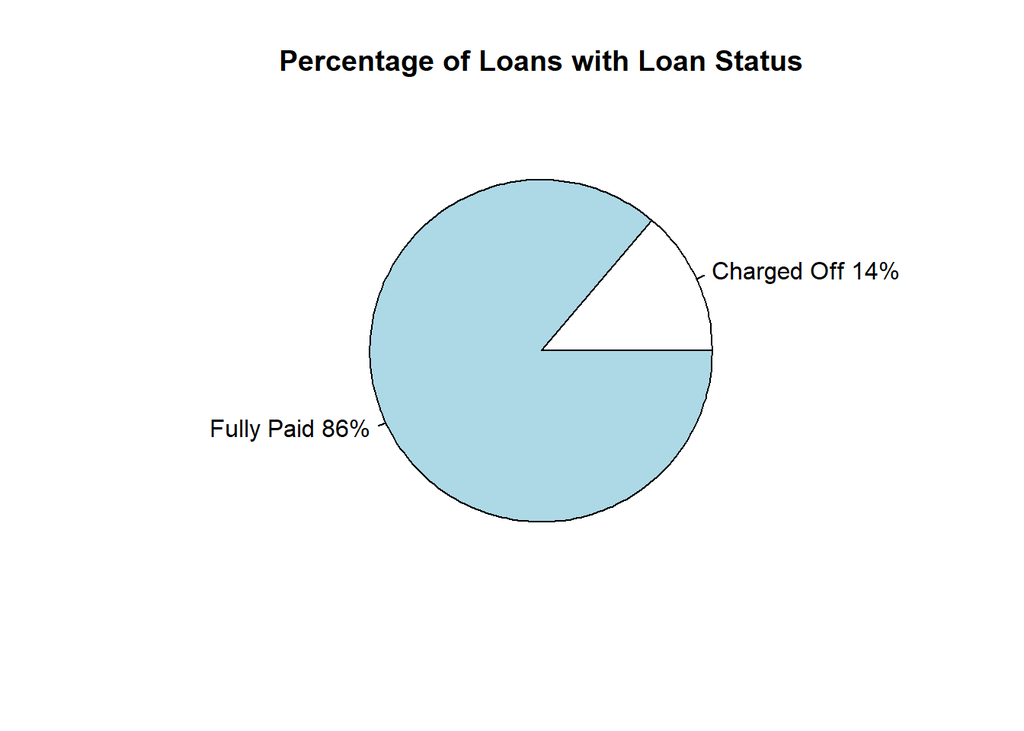

```r
loan_status_count <- lcdf %>% group_by(loan_status) %>% count()
pct <- round(loan_status_count$n/sum(loan_status_count$n)*100)
lbls <- paste(loan_status_count$loan_status, pct) # add percents to labels
lbls <- paste(lbls,"%",sep="") # ad % to labels


pie(loan_status_count$n, labels = lbls, main="Percentage of Loans with Loan Status")
```

Analyzing Home Ownerships

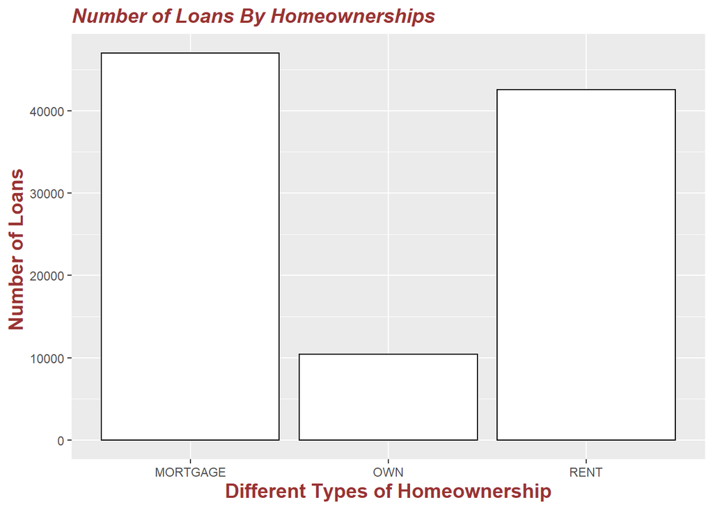

```r
ggplot(lcdf, aes( x = home_ownership)) + geom_bar(colour="black", fill="white") +ggtitle("Number of Loans By Homeownerships") + xlab("Different Types of Homeownership") + ylab("Number of Loans ") + theme(plot.title = element_text(color="#993333", size=14, face="bold.italic"), axis.title.x = element_text(color="#993333", size=14, face="bold"), axis.title.y = element_text(color="#993333", size=14, face="bold"))
```

We can see that most of the borrowers have their home on rent or mortgage as compared to those who own their homes.

Let’s now visualize the spread of interest rate to get a better understanding of the given data

```r
summary(lcdf$int_rate)
```

```
##    Min. 1st Qu.  Median    Mean 3rd Qu.    Max.
##    5.32    8.90   11.99   12.01   14.47   28.99
```

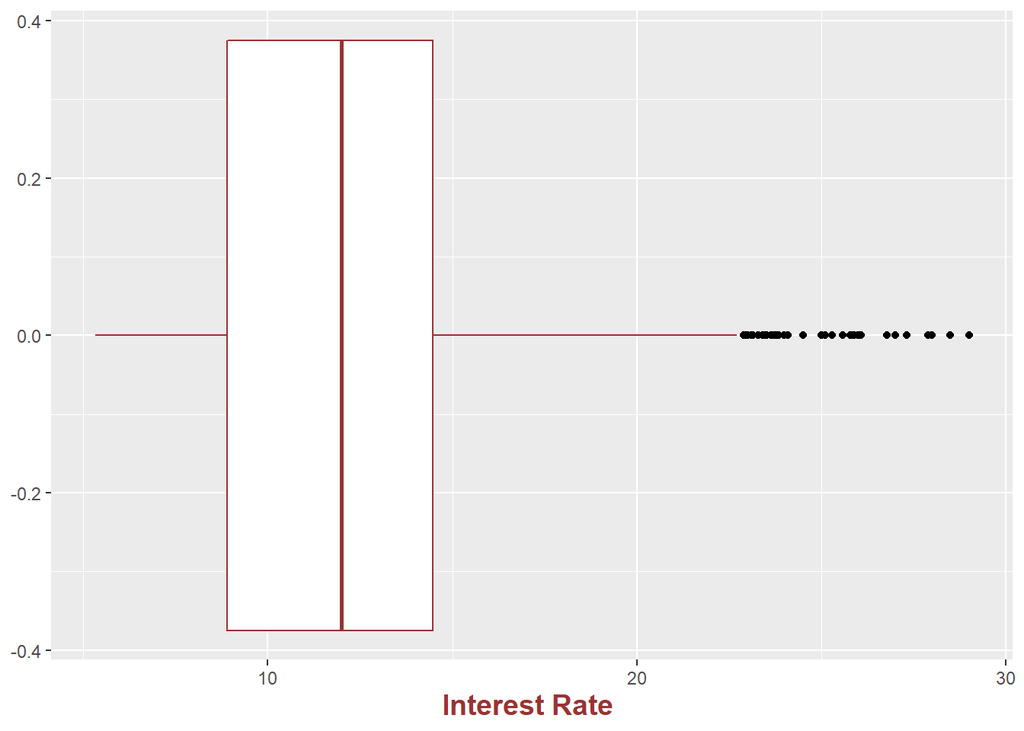

```r
ggplot(lcdf, aes( x = int_rate)) + geom_boxplot(color="#993333",outlier.color = "black") +
xlab("Interest Rate ")  + theme(plot.title = element_text(color="#993333", size=14, face="bold.italic"), axis.title.x = element_text(color="#993333", size=14, face="bold"), axis.title.y = element_text(color="#993333", size=14, face="bold"))
```

25 Percentile of loans have an interest rate of less than 8.9%. Median of the interest rate of all loans in 11.99%. The interest rate can go as high as 28.99 % in some case. This interest seems really active to invest in. Very few investment products give an interest of 12%.

Let’s understand interest rates vary according to loan grade

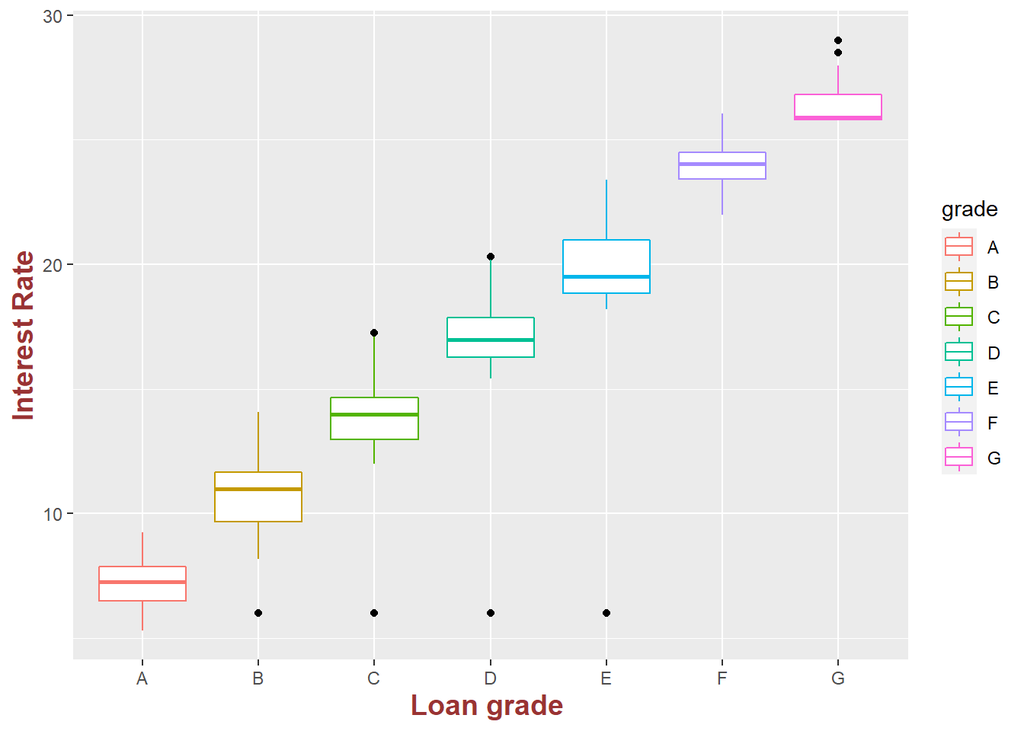

```r
ggplot(lcdf, aes( y = int_rate, x=grade,color= grade)) + geom_boxplot(outlier.color="black") + xlab("Loan grade ") +
ylab("Interest Rate")  + theme(plot.title = element_text(color="#993333", size=14, face="bold.italic"), axis.title.x = element_text(color="#993333", size=14, face="bold"), axis.title.y = element_text(color="#993333", size=14, face="bold"))
```

We can see that the median interest rate increases as we go from grade A to grade G, probably due to higher risk.

Let’s summarize the data to check percent of defaults using loan status for all loan grades

```r
lcdf %>% group_by(grade) %>% summarise(TotalLoans=n(), FullyPaid=sum(loan_status=="Fully Paid"), ChargedOff=sum(loan_status=="Charged Off"), Percent_defaults = ChargedOff/TotalLoans*100)
```

```
## # A tibble: 7 × 5
##   grade TotalLoans FullyPaid ChargedOff Percent_defaults
##   <chr>      <int>     <int>      <int>            <dbl>
## 1 A          22588     21401       1187             5.26
## 2 B          33907     30184       3723            11.0
## 3 C          26645     21907       4738            17.8
## 4 D          12493      9635       2858            22.9
## 5 E           3579      2569       1010            28.2
## 6 F            708       469        239            33.8
## 7 G             80        50         30            37.5
```

The percent of default loans is higher for lower grade loans. This explains why interest rates are higher for the same.

Now, let’s look at a wider picture to see how number of loans, loan amount, interest rate vary by grade. First, lets do some calculations

```r
# Number of Loans, Sum of Loan Amout, Mean Loan Amount Mean Int Rate by Grade
lcdf %>% group_by(grade) %>% summarise(numberOfLoans=n(), TotLoanAmt=sum(loan_amnt),MeanLoanAmt=mean(loan_amnt),defaults=sum(loan_status=="Charged Off"), defaultRate=defaults/numberOfLoans, Percent_defaults = defaultRate*100,MeanIntRate=mean(int_rate),stdInterest=sd(int_rate), minInt = min(int_rate),maxInt=max(int_rate),avgLoanAMt=mean(loan_amnt), sumPmnt=sum(total_pymnt),avgPmnt=mean(total_pymnt))
```

```
## # A tibble: 7 × 14
##   grade numberO…¹ TotLo…² MeanL…³ defau…⁴ defau…⁵ Perce…⁶ MeanI…⁷ stdIn…⁸ minInt
##   <chr>     <int>   <dbl>   <dbl>   <int>   <dbl>   <dbl>   <dbl>   <dbl>  <dbl>
## 1 A         22588  3.28e8  14505.    1187  0.0526    5.26    7.17   0.967   5.32
## 2 B         33907  4.28e8  12637.    3723  0.110    11.0    10.8    1.44    6
## 3 C         26645  3.20e8  12001.    4738  0.178    17.8    13.8    1.19    6
## 4 D         12493  1.49e8  11894.    2858  0.229    22.9    17.2    1.22    6
## 5 E          3579  4.16e7  11619.    1010  0.282    28.2    19.9    1.38    6
## 6 F           708  6.56e6   9272.     239  0.338    33.8    24.0    0.916  22.0
## 7 G            80  9.46e5  11826.      30  0.375    37.5    26.4    0.849  25.8
## # … with 4 more variables: maxInt <dbl>, avgLoanAMt <dbl>, sumPmnt <dbl>,
## #   avgPmnt <dbl>, and abbreviated variable names ¹numberOfLoans, ²TotLoanAmt,
## #   ³MeanLoanAmt, ⁴defaults, ⁵defaultRate, ⁶Percent_defaults, ⁷MeanIntRate,
## #   ⁸stdInterest
```